# Intro to R-workshop

Stephanie Long and Morgan Middlebrooks

4/16/2020

# Section 1: Programming in R Intro

# Authored by Stephanie Long

R in its most basic form can be used as a calculator.

```r
# addition
5 + 3
```

```
## [1] 8
```

```r
# subtraction
5 - 3
```

```
## [1] 2
```

```r
# multiplication
5 * 3
```

```
## [1] 15
```

```r
# division
5 / 3
```

```
## [1] 1.666667
```

```r
# find the remainder
5 %% 3
```

```
## [1] 2
```

```r
# exponentiation
3^2
```

```
## [1] 9
```

```r
# square root
sqrt(25)
```

```
## [1] 5
```

You can use R to assign values to variables to store for further use

```r
# assign 5 to x
x = 5

x
```

```
## [1] 5
```

```r
# another way to assign 4 to y
y <- 4

y
```

```
## [1] 4
```

```r
# yet another way

10 -> z

z
```

```
## [1] 10
```

```r
# assign 6 to new variable called "x4"
x4 = 6

# now we can use variables we created above to make a calculation
x * x4
```

```
## [1] 30
```

```r
#now we assign values to two variables
test_object <- 1.5
test_object_2 <- 2

# we can add variables together
test_object_2 + test_object
```

```
## [1] 3.5
```

You can also test logical operators

```r
# using our stored values we can compare variables
# is z greater than x?
z > x
```

```
## [1] TRUE
```

```r
# is x less than y?
x < y
```

```
## [1] FALSE
```

```r
# is z greater than or equal to x?
z >= x
```

```
## [1] TRUE
```

```r
# is z equal to y?
z == y
```

```
## [1] FALSE
```

```r
# is the value of z - 6 equal to y?
z - 6 == y
```

```
## [1] TRUE
```

```r
# is z not equal to y?
z != y
```

```
## [1] TRUE
```

Finally, variables (or objects) in R are stored as certain data types

```r
# 1) numeric
typeof(x)
```

```
## [1] "double"
```

```r
# 2) character
l <- "this is a list"
typeof(l)
```

```
## [1] "character"
```

```r
# 3) logical
typeof(TRUE)
```

```
## [1] "logical"
```

```r
# 4) list (contains multiple data types)
my_list <-list("a" = 2.5, "b" = TRUE, "c" = 1:3)
typeof(my_list)
```

```
## [1] "list"
```

```r
# these are all vectors (1 dimension objects)

# there are also 2 dimensional objects

# 1 matrix (contains rows and columns)
my_matrix <- matrix(data = c(1, 2, 3,
                             4, 5, 6,
                             7, 8, 9), nrow = 3, ncol = 3)
my_matrix
```

```
##      [,1] [,2] [,3]
## [1,]    1    4    7
## [2,]    2    5    8
## [3,]    3    6    9
```

```r
str(my_matrix)
```

```
##  num [1:3, 1:3] 1 2 3 4 5 6 7 8 9
```

```r
# 2 data frame (contains observations (rows) and variables (columns))
my_dataframe <- as.data.frame(my_matrix)
str(my_dataframe)
```

```
## 'data.frame':    3 obs. of  3 variables:
##  $ V1: num  1 2 3
##  $ V2: num  4 5 6
##  $ V3: num  7 8 9
```

```r
# what sets this apart from matrices is that you can call on variables by their name using "$"
my_dataframe$V1
```

```
## [1] 1 2 3
```

# Section 2: ANOVA Basics

# Authored by Morgan Middlebrooks

First you need to understand what an ANOVA is even doing/ what sort of data is appropriate for it.

An ANOVA is basically just seeing if there is statistically significant difference between the groups of a IV on some outcome variable.

It’s important to consider what TYPE of data you need in ANOVA. You need the IV to be categorical (remember, we’re comparing groups aka categories) and the DV needs to be continuous.

An ANOVA also wants the groups to have equal variance.

```r
library(tidyverse)
# first we will load in our data
load(file = "Movie Data.Rdata")

#shows us what's inside the data
head(movie_data)
```

```
##                       movie_title release_date     genre MPAA_rating
## 1 Snow White and the Seven Dwarfs   1937-12-21   Musical           G
## 2                       Pinocchio   1940-02-09 Adventure           G
## 3                        Fantasia   1940-11-13   Musical           G
## 4               Song of the South   1946-11-12 Adventure           G
## 5                      Cinderella   1950-02-15     Drama           G
## 6    20,000 Leagues Under the Sea   1954-12-23 Adventure        <NA>
##   total_gross inflation_adjusted_gross
## 1   184925485               5228953251
## 2    84300000               2188229052
## 3    83320000               2187090808
## 4    65000000               1078510579
## 5    85000000                920608730
## 6    28200000                528279994
```

```r
# need to remove incomplete cases of data aka "NA"
movie_data <- movie_data[complete.cases(movie_data$genre),]
```

Next we will subset the data.

We’re going to pick the genres with the largest cell sizes that are closest to equal.

```r
## It looks like Adventure, Comedy, and Drama are our closest to equal cell
## sizes
group_by(movie_data, genre) %>%
  summarise(
    count = n())
```

```
## # A tibble: 12 x 2
##    genre               count
##    <fct>               <int>
##  1 Action                 40
##  2 Adventure             129
##  3 Black Comedy            3
##  4 Comedy                182
##  5 Concert/Performance     2
##  6 Documentary            16
##  7 Drama                 114
##  8 Horror                  6
##  9 Musical                16
## 10 Romantic Comedy        23
## 11 Thriller/Suspense      24
## 12 Western                 7
```

```r
anova.df <- subset(movie_data, genre %in% c('Adventure','Comedy', 'Drama'))

group_by(anova.df, genre) %>%
  summarise(
    count = n())
```

```
## # A tibble: 3 x 2
##   genre     count
##   <fct>     <int>
## 1 Adventure   129
## 2 Comedy      182
## 3 Drama       114
```

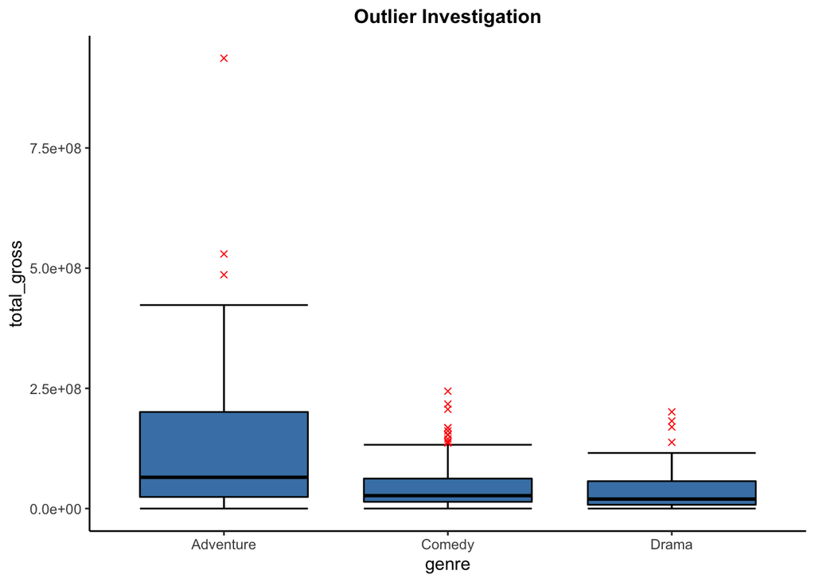

```r
## Boxplot to look at outliers

outlier.invest <- ggplot(anova.df, aes(genre, total_gross)) +
  stat_boxplot(geom = 'errorbar') +
  geom_boxplot(fill = "steelblue", colour = "black", outlier.colour = "red", outlier.shape = 4) +
  ggtitle("Outlier Investigation") +
  theme_classic() +
  theme(plot.title = element_text(lineheight=.8, face="bold", hjust = .5, size = 12, colour = "black"))

outlier.invest
```

It looks like we have some pretty serious outliers.

Now we will demonstrate one way of removing outliers. I want to emphasize that this is NOT the most statistically sound way. There are lots of other ways to consider outliers. We don’t have time for a whole session on outliers & data cleaning. So this is just a quick and dirty way!

```r
outliers <- boxplot(anova.df$total_gross, plot=FALSE)$out  ## this saves a list of outliers

print(outliers)  ## This shows you each total_gross value that is an outlier in the list we just saved. We've got several...
```

```
##  [1] 217350219 422780140 191796233 201578182 245852179 289423425 380529370
##  [8] 305411224 261441092 291710957 244082982 423315812 309420425 206445654
## [15] 219961501 223808164 293004164 334191110 415004880 200821936 241063875
## [22] 191450875 237282182 189412677 182207973 234770996 268488329 206362140
## [29] 400738009 241407328 333172112 222527828 201151353 356461711 936662225
## [36] 341268248 364001123 486295561 232532923 246082029 529483936
```

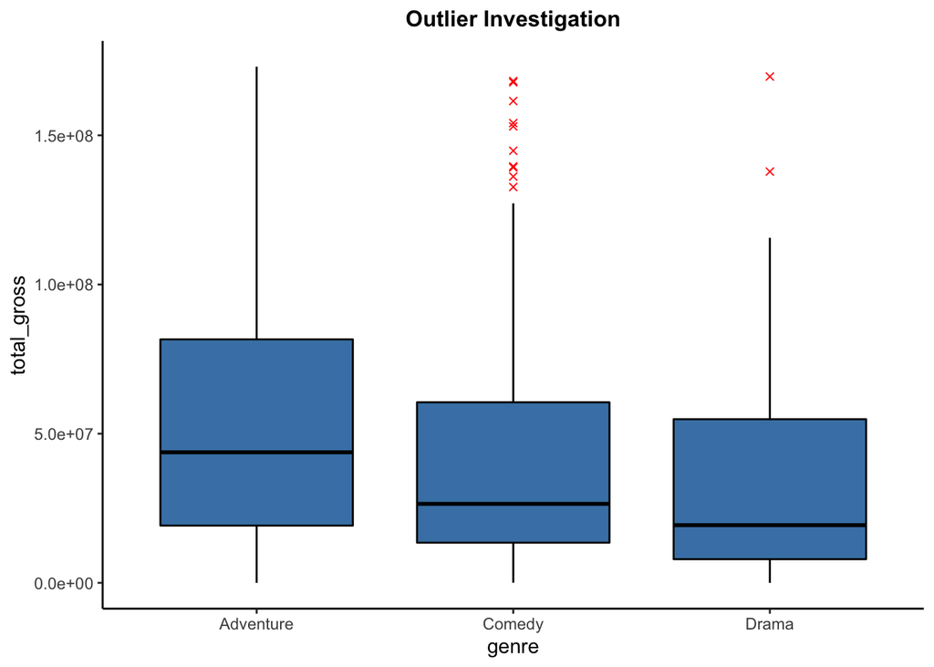

```r
anova.df.out <- anova.df[-which(anova.df$total_gross %in% outliers),] #this creates a data frame the removes those outliers. Notice the " - which "

## Another boxplot to check if our work, worked out.

outlier.invest.2 <- ggplot(anova.df.out, aes(genre, total_gross)) +
  geom_boxplot(fill = "steelblue", colour = "black", outlier.colour = "red", outlier.shape = 4) +
  ggtitle("Outlier Investigation") +
  theme_classic() +
  theme(plot.title = element_text(lineheight=.8, face="bold", hjust = .5, size = 12, colour = "black"))

outlier.invest.2
```

We still have some after a basic outlier removal that look like outliers, but were not classified using the above method. There are lots of fancy ways you can check if those are TRUE outliers (using Cook’s d for example), but we’re not doing that today.

Notice how the bars are stretched more similarly now.

Now we will check the groups for equal variance since this is another important aspect of an ANOVA.

```r
car::leveneTest(total_gross ~ genre, data = anova.df.out)
```

```
## Levene's Test for Homogeneity of Variance (center = median)
##        Df F value  Pr(>F)
## group   2  3.2388 0.04029 *
##       381
## ---
## Signif. codes:  0 '***' 0.001 '**' 0.01 '*' 0.05 '.' 0.1 ' ' 1
```

There is a difference, but barely. A better scientist would not let this slide. The groups should have equal variance!

Now we can move on to the ANOVA and interpretation.

```r
mod <- aov(total_gross ~ genre, data = anova.df.out)

summary(mod)
```

```
##              Df    Sum Sq   Mean Sq F value   Pr(>F)
## genre         2 2.437e+16 1.218e+16   7.883 0.000442 ***
## Residuals   381 5.889e+17 1.546e+15
## ---
## Signif. codes:  0 '***' 0.001 '**' 0.01 '*' 0.05 '.' 0.1 ' ' 1
```

There is a difference in genre….but WHERE YOU ASK?

Now we can do post-hoc tests to find where the significant difference in genres is.

```r
TukeyHSD(mod)
```

```
##   Tukey multiple comparisons of means
##     95% family-wise confidence level
##
## Fit: aov(formula = total_gross ~ genre, data = anova.df.out)
##
## $genre
##                       diff       lwr      upr     p adj
## Comedy-Adventure -13419137 -25243761 -1594512 0.0215165
## Drama-Adventure  -21802423 -34780112 -8824735 0.0002708
## Drama-Comedy      -8383287 -19528333  2761760 0.1811636
```

```r
## Difference between comedy + adventure
## Difference between drama + adventure
## No difference in drama + comedy

group_by(anova.df, genre) %>%
  summarise(
    count = n(),
    mean = mean(total_gross, na.rm = TRUE),
    sd = sd(total_gross, na.rm = TRUE)
  )
```

```
## # A tibble: 3 x 4
##   genre     count       mean         sd
##   <fct>     <int>      <dbl>      <dbl>
## 1 Adventure   129 127047050. 142143457.
## 2 Comedy      182  44613295.  45550875.
## 3 Drama       114  36026079.  38794051.
```

```r
## adventure makes way more money here
```

Check out boxplots below to really send message home that you’re going to make more money on adventure.

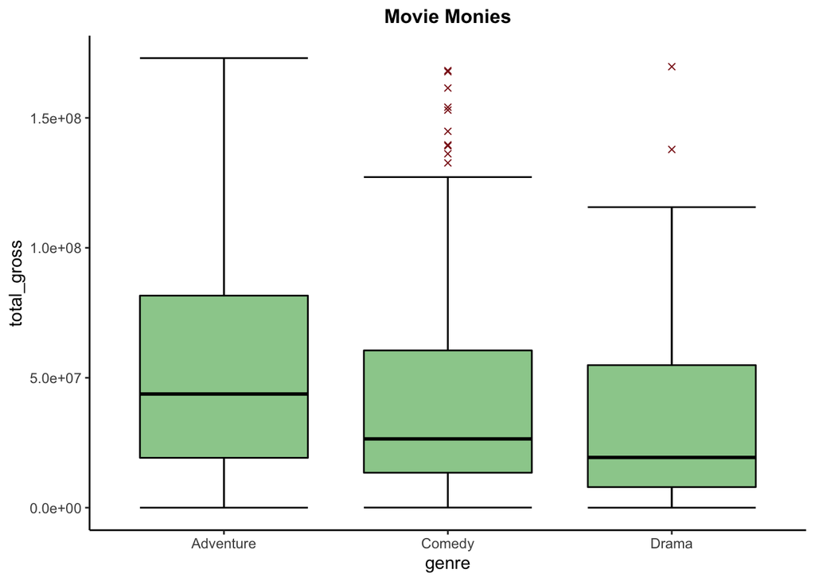

```r
ggplot(anova.df.out, aes(genre, total_gross)) +
  stat_boxplot(geom = 'errorbar') +
  geom_boxplot(fill = "darkseagreen3", colour = "black", outlier.colour = "firebrick4", outlier.shape = 4) +
  ggtitle("Movie Monies") +
  theme_classic() +
  theme(plot.title = element_text(lineheight=.8, face="bold", hjust = .5, size = 12, colour = "black"))
```

Looking at this plot (which is the same as investigation plot 2, btw. I’ve just change the labels here) you can see that Adventure’s mean is higher than both comedy and drama, but comedy and drama aren’t that different.

# Section 3: Data Visualization of Movie Genre Revenue

# Authored by Stephanie Long

We will continue to use the movie_data dataset from above but we need to clean up a few things

```r
# removing genre groups with less than 10 movies
large_sample_genre <- filter(movie_data, genre != "Black Comedy" & genre != "Concert/Performance" & genre != "Horror" & genre != "Western")
summary(large_sample_genre$genre)
```

```
##              Action           Adventure        Black Comedy              Comedy
##                  40                 129                   0                 182
## Concert/Performance         Documentary               Drama              Horror
##                   0                  16                 114                   0
##             Musical     Romantic Comedy   Thriller/Suspense             Western
##                  16                  23                  24                   0
```

```r
## adding two columns to divide by 1 billion, so the y-axis of the plots makes more sense
large_sample_genre$total_gross_billion <- large_sample_genre$total_gross/1000000000
large_sample_genre$adj_gross_billion <- large_sample_genre$inflation_adjusted_gross/1000000000
```

Our first plot will be a simple boxplot

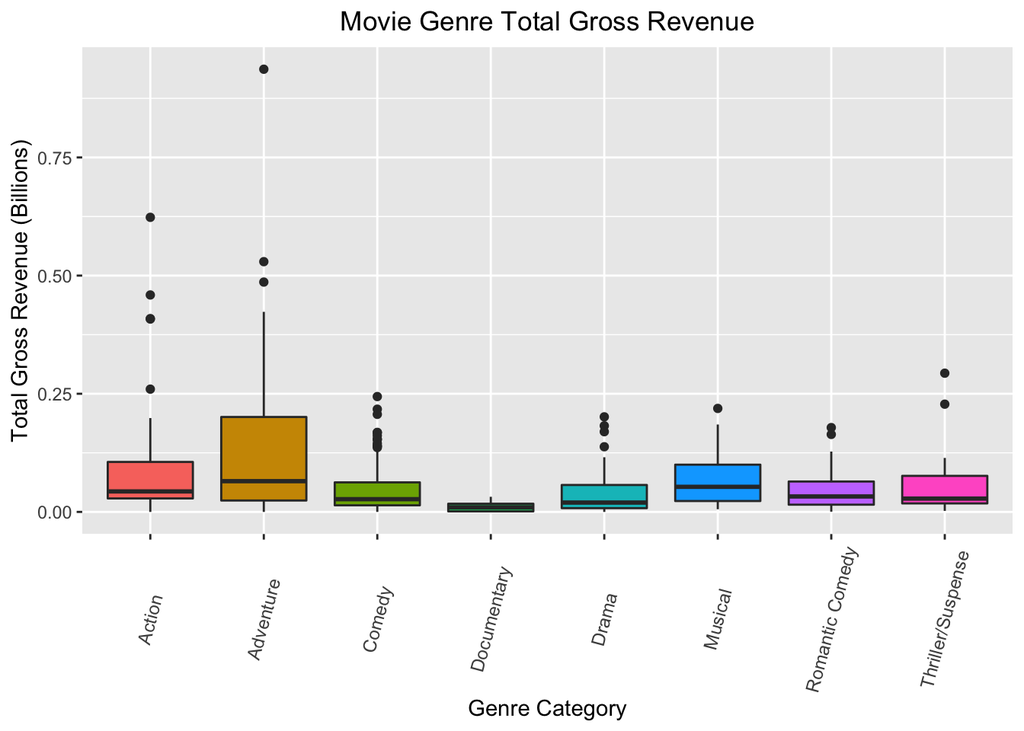

```r
plot1 <- ggplot(data = large_sample_genre) + # call our data layer to the plot
  geom_boxplot(aes(x = genre, # adding our boxplot data, this line adds our x-axis
                   y = total_gross_billion, # add our y-axis
                   fill = genre)) + # fill the boxes with color based on or genre groups
  theme(axis.text.x  = element_text(angle=75, vjust=0.5, size=9), # adjust the x-axis text so that it's angled and larger
        legend.position = "none", # remove the legend since you can see what groups the colors belong to
        plot.title = element_text(hjust = 0.5)) + # adjust our title to be in the center
  labs(x = "Genre Category", # re-title the x-axis label
       y = "Total Gross Revenue (Billions)", # re-title the y-axis label
       title = "Movie Genre Total Gross Revenue") # add the title
plot1
```

Our second plot will demonstrate two bar graphs including errorbars

The plot will show mean gross revenue for both adjusted and non-adjusted for inflation for each genre and include standard error for revenue type across genres as errorbars. Standard error is a measurement of how much a sample mean deviates from the population mean and is pretty standard for plotting errorbars.

We’ll start with a cleaned up and organized dataset created from the movie_data

```r
load("Plot 2 cleaned data.Rdata")
str(plot_data2)
```

```
## 'data.frame':    16 obs. of  5 variables:
##  $ genre       : Factor w/ 12 levels "Action","Adventure",..: 1 1 2 2 4 4 6 6 7 7 ...
##  $ Revenue_Type: Factor w/ 2 levels "Inflation Adjusted",..: 2 1 2 1 2 1 2 1 2 1 ...
##  $ MRevenue    : num  0.1046 0.1375 0.127 0.1904 0.0446 ...
##  $ SE_Type     : chr  "total_se" "adj_se" "total_se" "adj_se" ...
##  $ SE          : num  0.02215 0.02298 0.01252 0.02242 0.00338 ...
```

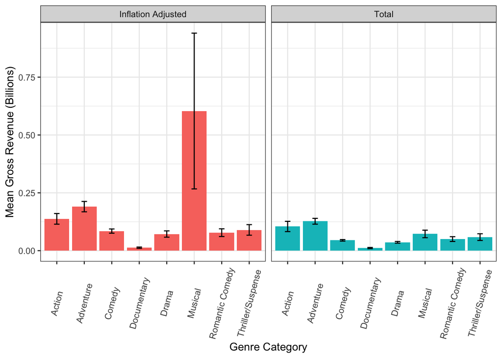

```r
# same general set-up
plot2 <- ggplot(data = plot_data2,
                aes(x = genre,
                    y = MRevenue,
                    fill = Revenue_Type)) + # our colors here will reflect adjusted or total revenue
  geom_bar(stat = "identity") + # adding our bar graph by assigning the height of the bar to be our MRevenue
  theme_bw() + # adding a new more plain theme as our background
  theme(axis.text.x  = element_text(angle=75, vjust=0.5, size=9),
        legend.position = "none") +
  facet_wrap(~Revenue_Type) + # adding a "facet" so that there are two graphs plotted side by side
  labs(x = "Genre Category",
       y = "Mean Gross Revenue (Billions)") +
  geom_errorbar(aes(ymin=MRevenue-SE, ymax=MRevenue+SE), width=.2, position=position_dodge(.9)) #adding our errorbars as standard error
plot2
```

Our third plot will display trend lines for each genre’s inflation adjusted revenue over time.

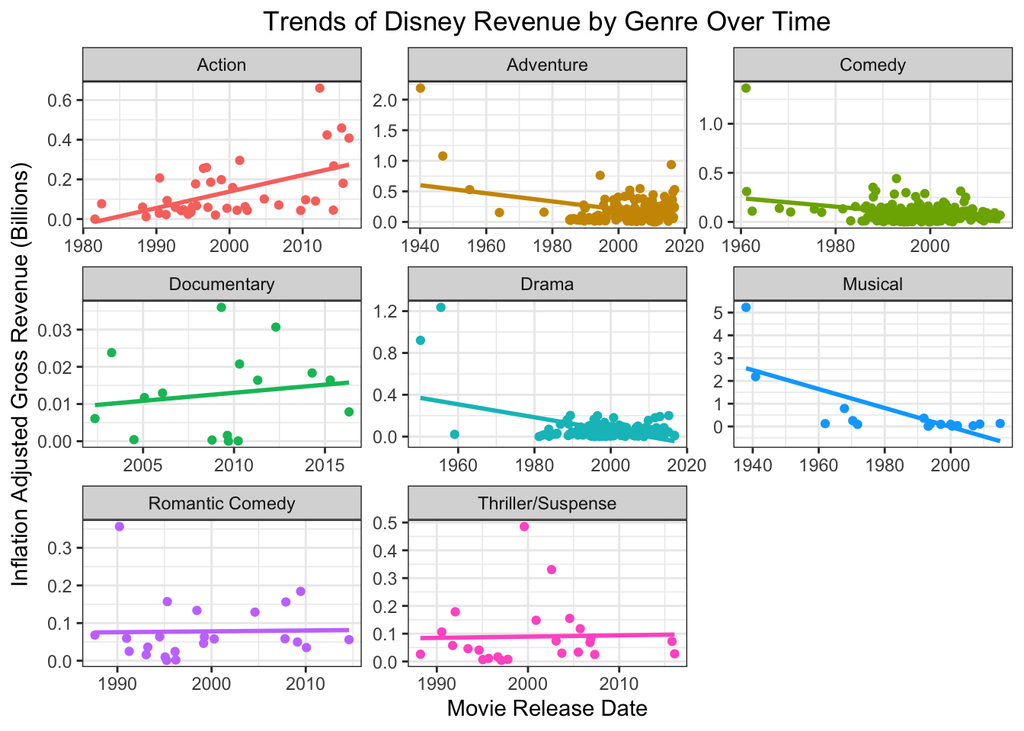

```r
plot3 <- ggplot(data = large_sample_genre) +
  geom_point(aes(x = release_date,   # here is where we add our data points
                 y = inflation_adjusted_gross/1000000000,
                 color = genre)) +
  geom_smooth(aes(x = release_date,
                  y = inflation_adjusted_gross/1000000000,
                  color = genre),
              method = "lm", se = F) + # adding a linear trendline based on "lm" or linear regression model
  facet_wrap(~genre, scales = "free") + # adding individual graphs for each genre and allowing the y axis to scale for each
  theme_bw() +
  theme(legend.position = "none",
        plot.title = element_text(hjust = 0.5)) +
  labs(x = "Movie Release Date",
       y = "Inflation Adjusted Gross Revenue (Billions)",
       title = "Trends of Disney Revenue by Genre Over Time")
plot3
```

Finally, our fourth plot will compare the top 25 grossing movies comparing the adjusted and non-adjusted revenues.

```r
library("patchwork") # package for combining plots

#pulling just the top 25 total grossing movies
top_total_25 <- movie_data %>%
  arrange(desc(total_gross)) %>% #arranges the data in descending order by "total_gross"
  slice(1:25) # slices just the top 25

top_total_25
```

```
##                               movie_title release_date             genre
## 1    Star Wars Ep. VII: The Force Awakens   2015-12-18         Adventure
## 2                            The Avengers   2012-05-04            Action
## 3            Rogue One: A Star Wars Story   2016-12-16         Adventure
## 4                            Finding Dory   2016-06-17         Adventure
## 5                 Avengers: Age of Ultron   2015-05-01            Action
## 6    Pirates of the Caribbean: Dead Man’…   2006-07-07         Adventure
## 7                           The Lion King   1994-06-15         Adventure
## 8                             Toy Story 3   2010-06-18         Adventure
## 9                              Iron Man 3   2013-05-03            Action
## 10             Captain America: Civil War   2016-05-06            Action
## 11                                 Frozen   2013-11-22         Adventure
## 12                           Finding Nemo   2003-05-30         Adventure
## 13                        The Jungle Book   2016-04-15         Adventure
## 14                             Inside Out   2015-06-19         Adventure
```

[output cut: 37 more lines]

```r
#pulling just the top 25 grossing movies adjusted for inflation
top_adj_25 <- movie_data %>%
  arrange(desc(inflation_adjusted_gross)) %>%
  slice(1:25)

top_adj_25
```

```
##                               movie_title release_date             genre
## 1         Snow White and the Seven Dwarfs   1937-12-21           Musical
## 2                               Pinocchio   1940-02-09         Adventure
## 3                                Fantasia   1940-11-13           Musical
## 4                          101 Dalmatians   1961-01-25            Comedy
## 5                      Lady and the Tramp   1955-06-22             Drama
## 6                       Song of the South   1946-11-12         Adventure
## 7    Star Wars Ep. VII: The Force Awakens   2015-12-18         Adventure
## 8                              Cinderella   1950-02-15             Drama
## 9                         The Jungle Book   1967-10-18           Musical
## 10                          The Lion King   1994-06-15         Adventure
## 11                           The Avengers   2012-05-04            Action
## 12   Pirates of the Caribbean: Dead Man’…   2006-07-07         Adventure
## 13           Rogue One: A Star Wars Story   2016-12-16         Adventure
## 14           20,000 Leagues Under the Sea   1954-12-23         Adventure
```

[output cut: 37 more lines]

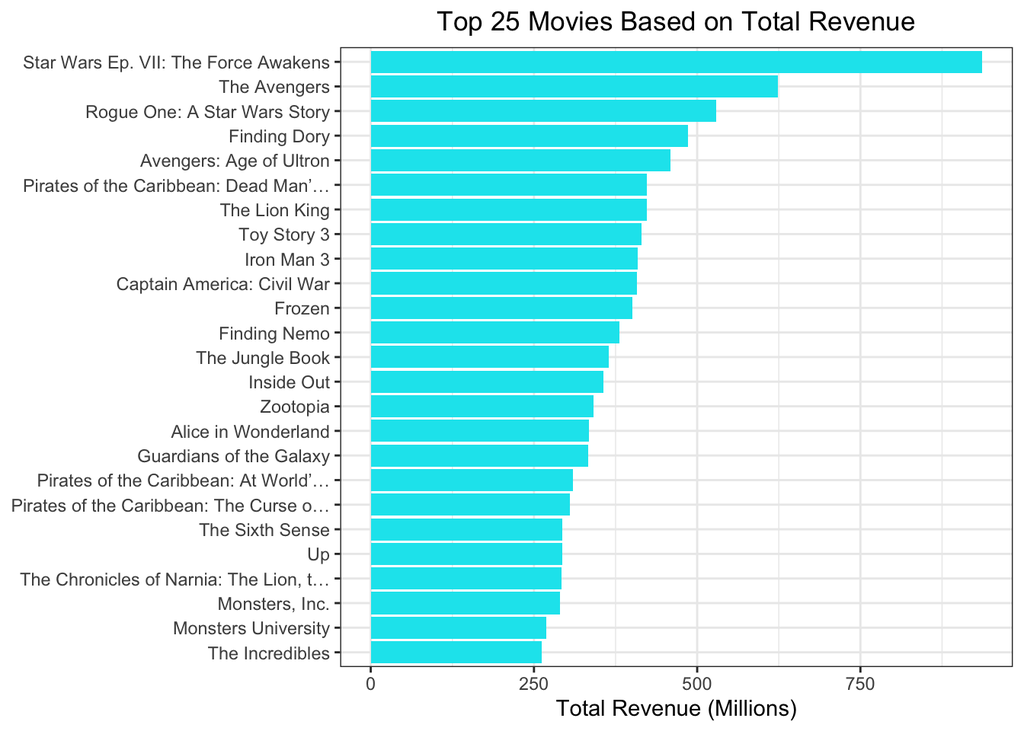

```r
#combining the data and converting for graphing (don't worry about this part)
top_25 <- merge(top_total_25[,c(1,5)], top_adj_25[,c(1,6)], all = T, by = "movie_title")
top_25_pivot <- pivot_longer(top_25, cols = c("total_gross", "inflation_adjusted_gross"), names_to = "Type", values_to = "Revenue")

# we're going to make two separate graphs of our top 25 movies and then combined them

# plot 4A: top 25 based on "total_gross"
total <- ggplot(data = top_total_25,
                aes(x = reorder(movie_title, total_gross), # we can arrange our bars to be descending from greatest to least
                    y = (total_gross/1000000))) + # we can divide the y axis so it's showing Millions instead of Billions
  geom_bar(stat = "identity", position = "dodge", fill = "turquoise2") + # change the color of our bars with "fill"
  theme_bw() +
  coord_flip() + # we can flip our x and y coordinates
  theme(axis.title.y = element_blank(), # remove the y axis title since we all the movies are labeled
        legend.position = "none",
        plot.title = element_text(hjust = 0.5))+
  labs(y = "Total Revenue (Millions)", # make sure our labels go with our data
       title = "Top 25 Movies Based on Total Revenue")
total
```

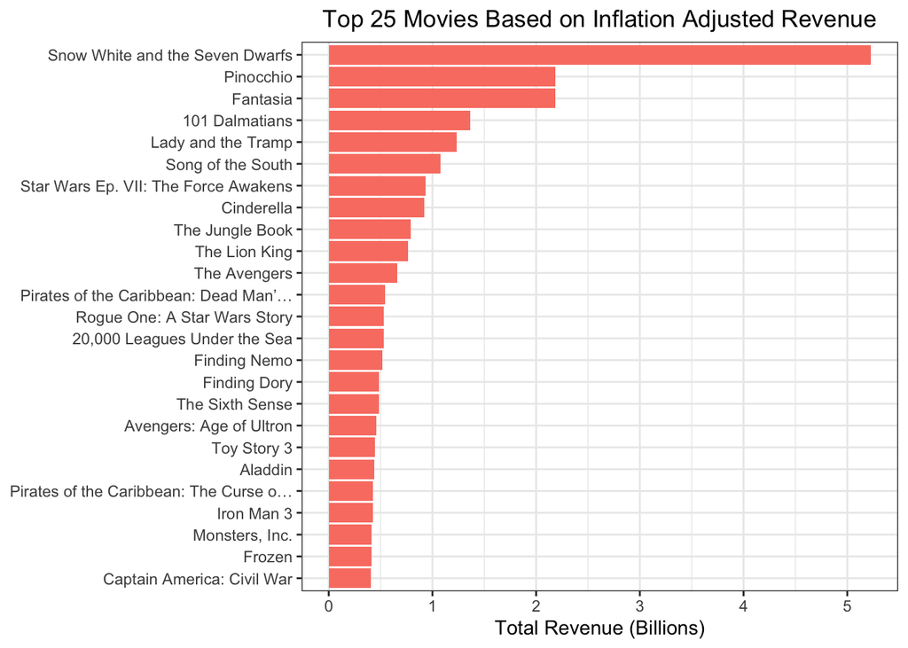

```r
# plot 4B: top 25 based on "inflation_adjusted_gross"
adj <- ggplot(data = top_adj_25,
              aes(x = reorder(movie_title, inflation_adjusted_gross), y = (inflation_adjusted_gross/1000000000))) +
  geom_bar(stat = "identity", position = "dodge", fill = "salmon") +
  theme_bw() +
  coord_flip() +
  theme(axis.title.y = element_blank(),
        legend.position = "none",
        plot.title = element_text(hjust = 0.5))+
  labs(y = "Total Revenue (Billions)",
       title = "Top 25 Movies Based on Inflation Adjusted Revenue")
adj
```

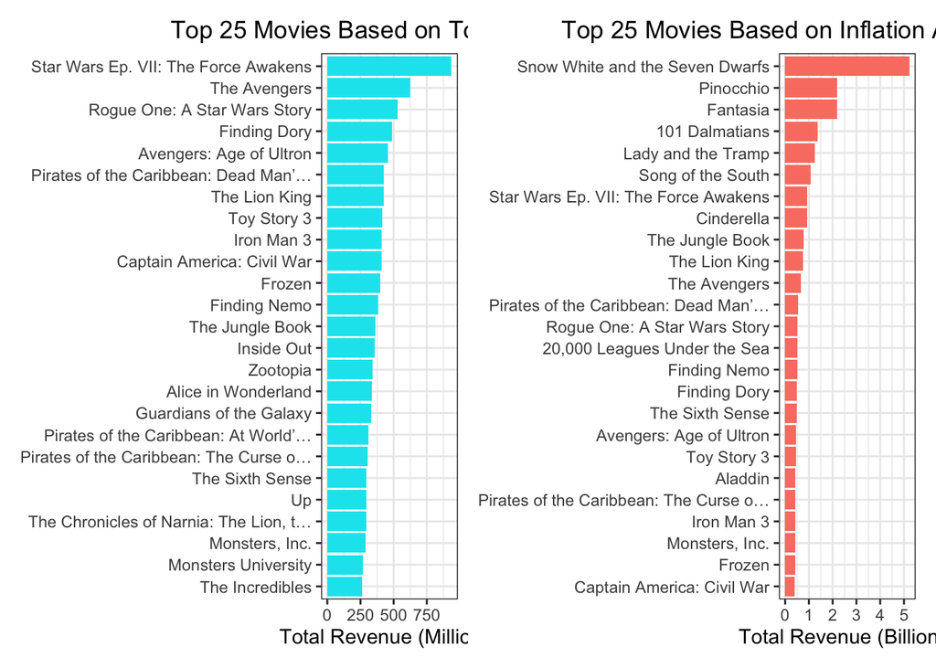

```r
# combining plot 4A and 4B
plot4 <- total | adj
plot4
```